[figure not shown]

# Байесовские методы

В этой тетрадке мы попробуем поработать с библиотекой pymc3.

```python
import numpy as np
import pandas as pd

from scipy import stats

import seaborn as sns
import matplotlib.pyplot as plt

plt.style.use('ggplot')
%matplotlib inline
```

```python
import warnings
warnings.filterwarnings('ignore')
```

```python
# !pip3 install pymc3
```

```python
import pymc3 as pm
pm.__version__
```

```
'3.9.3'
```

# 1. Петя и караси

Сгенерируем из распределения Бернулли с $p=0.3$ выборку карасей и щук

```python
y = stats.bernoulli(p=0.3).rvs(100)
print('Доля карасей в выборке:', y.mean())
y
```

```
Доля карасей в выборке: 0.36
```

```
array([0, 1, 1, 1, 1, 0, 0, 1, 0, 0, 1, 0, 0, 0, 0, 0, 0, 0, 0, 1, 0, 1,
       0, 0, 0, 0, 0, 0, 1, 0, 1, 0, 1, 1, 1, 0, 0, 1, 1, 0, 1, 0, 0, 1,
       1, 1, 1, 1, 1, 0, 0, 0, 0, 1, 0, 1, 1, 1, 0, 0, 0, 1, 0, 0, 0, 1,
       0, 1, 0, 0, 1, 0, 0, 1, 0, 1, 0, 0, 0, 0, 0, 0, 1, 1, 0, 0, 0, 0,
       0, 0, 0, 0, 0, 0, 1, 0, 1, 0, 0, 0])
```

Задаём нашу модель и априорное распределение.

```python
basic_model = pm.Model()

with basic_model:
    p = pm.Uniform(name="karases_prop", lower=0, upper=1)   # априорное распределение для доли
    y_obs = pm.Bernoulli(name='y_obs', p = p, observed=y)   # модель
```

Байесовские методы для бедных: находим оценку моды апостериорного распределения. Её можно использовать в качестве точечной байесовской оценки. Когда мы не можем найти знаменатель в формуле Байеса, единственное, что нам остаётся - посчитать моду.

```python
map_estimate = pm.find_MAP(model=basic_model)
map_estimate
```

100.00% [6/6 00:00<00:00 logp = -69.315, ||grad|| = 14]

```
{'karases_prop_interval__': array(-0.57536415), 'karases_prop': array(0.36)}
```

Но, конечно же, лучше получить апостериорное распределение полностью. Для этого запустим 500 итераций MCMC.

```python
with basic_model:
    trace = pm.sample(500, return_inferencedata=False, model=basic_model)
```

```
Auto-assigning NUTS sampler...
Initializing NUTS using jitter+adapt_diag...
Multiprocess sampling (4 chains in 4 jobs)
NUTS: [karases_prop]
```

100.00% [6000/6000 00:02<00:00 Sampling 4 chains, 0 divergences]

```
Sampling 4 chains for 1_000 tune and 500 draw iterations (4_000 + 2_000 draws total) took 12 seconds.
The acceptance probability does not match the target. It is 0.8910210126381999, but should be close to 0.8. Try to increase the number of tuning steps.
```

Посмотрим, что у нас получилось. Апостериорное распределенеи параметра лежит в переменной `trace` по ключу с её названием.

```python
# Последние 5 значений в выборке
trace["karases_prop"][-5:]
```

```
array([0.40908677, 0.40908677, 0.39683452, 0.39683452, 0.39683452])
```

```python
# размер выборки
trace["karases_prop"].shape
```

```
(2000,)
```

С помощью пакета `arviz` можно провалидировать обучение модели и посмотреть на краткое саммари.

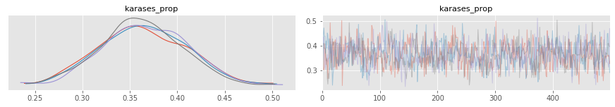

```python
import arviz as az
az.plot_trace(trace);
```

Алгоритм запустится $4$ раза. Слева будут отрисованы апостериорные распределения (сглаженные и отнормированные гистограммы для апостериорных выборок, полученныех в результате MCMC). Справа будет график истории марковской цепи. Анализируя ее, можно понять, насколько хорошо отработал алгоритм и требует ли он дополнительной настройки. Визуальными критериями качества являются:

- Стационарность. Сэмплы должны образовывать шум вогруг какого-то значения.
- Не имеют сильно выраженной автокорреляции.
- Вся история не может стостоять из одной и той же повторяющейся точки. Если какая-то переменная оставалась константой, то скорее всего что-то пошло не так.

Понятное дело, что итерации, указанные нами в опциях алгоритма для прогрева не входят в итоговую выборку.

```python
az.summary(trace, round_to=2)
```

|  | mean | sd | hdi_3% | hdi_97% | mcse_mean | mcse_sd | ess_mean | ess_sd | ess_bulk | ess_tail | r_hat |
| --- | --- | --- | --- | --- | --- | --- | --- | --- | --- | --- | --- |
| karases_prop | 0.36 | 0.05 | 0.28 | 0.45 | 0.0 | 0.0 | 929.96 | 929.96 | 931.4 | 1245.29 | 1.0 |

Обратите внимание на колонку `r_hat`. Грубо говоря, это отношение дисперсий между цепями к десперсии внутри цепей. Это значение должно быть близко к $1$, иначе разные цепи ведут себя не одинаково и с алгоритмом есть проблемы.

**Визуализация MCMC:** https://chi-feng.github.io/mcmc-demo/

# 2. Структурный сдвиг

Проанализируем данные по авариям на шахтах в Англии. Они собираются с 19 века.

```python
df = pd.read_csv('coals.csv', index_col=0)
print(df.shape)
df.head()
```

```
(112, 2)
```

|  | year | count |
| --- | --- | --- |
| 1 | 1851 | 4 |
| 2 | 1852 | 5 |
| 3 | 1853 | 4 |
| 4 | 1854 | 1 |
| 5 | 1855 | 0 |

Посмотрим на то, как число аварий ведёт себя в динамике. Можно заметить, что в 20 веке аварий стало меньше. Судя по всему, работать в шахтах стало безопаснее. Было бы интересно найти момент, когда произошёл структурный сдвиг.

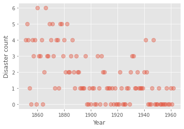

```python
years = df['year'].values
y = df['count'].values

plt.plot(years, y, "o", markersize=8, alpha=0.4)
plt.ylabel("Disaster count")
plt.xlabel("Year");
```

Попробуем оценить момент структурного сдвига с помощью Байесовских методов. Число аварий - случайная величина счётчик. Для моделирования счётчиков отлично подходит распределение Пуассона:

$$ Y_t \sim Poiss(\lambda) $$

Мы не знаем значения $\lambda$ и предполагаем, что где-то между $19$ и $20$ веками произошёл структурный сдвиг. Работать на шахтах стало безопаснее. Хочется найти наиболее вероятный момент этого сдвига. Специфицируем модель следующим образом:

$$ \lambda = \begin{cases} \lambda_1, \text{ если } t < \tau \\ \lambda_2, \text{ если } t \ge \tau \end{cases} $$

Если в реальности никакого сдвига нет, то окажется, что $\lambda_1 = \lambda_2$. Апостериорные распределения этих параметров будут выглядеть практически одинаково. Про эти значения мы знаем, что они должны быть положительными. Зададим это знание с помощью априорных распределений:

$$ \lambda_1 \sim Exp(\alpha), \quad \lambda_2 \sim Exp(\alpha) $$

Параметр $\alpha$ здесь - это гиперпараметр. Про него мы ничего не знаем. Для него можно также завести своё априорное распределение. Например, нормальное с высокой дисперсией. Либо можно выставить его таким, чтобы для $\lambda_i$ дисперсия оказалась высокой.

```python
alpha = 0.1
1/alpha**2
```

```
99.99999999999999
```

```python
with pm.Model() as disaster_model:

    # априорные распределения для параметров:
    tau = pm.DiscreteUniform("tau", lower=years.min(), upper=years.max())

    early_rate = pm.Exponential("early_rate", alpha)
    late_rate = pm.Exponential("late_rate", alpha)

    # разные значения lambda в зависимости от tau
    rate = pm.math.switch(tau >= years, early_rate, late_rate)

    # связь y с rate
    y_obs = pm.Poisson("disasters", rate, observed=y)
```

Запускаем MCMC.

```python
with disaster_model:
    trace = pm.sample(10000, return_inferencedata=False, model=disaster_model)
```

```
Multiprocess sampling (4 chains in 4 jobs)
CompoundStep
>Metropolis: [tau]
>NUTS: [late_rate, early_rate]
```

100.00% [44000/44000 00:15<00:00 Sampling 4 chains, 0 divergences]

```
Sampling 4 chains for 1_000 tune and 10_000 draw iterations (4_000 + 40_000 draws total) took 25 seconds.
The number of effective samples is smaller than 25% for some parameters.
```

Посмотрим что получилось на графиках.

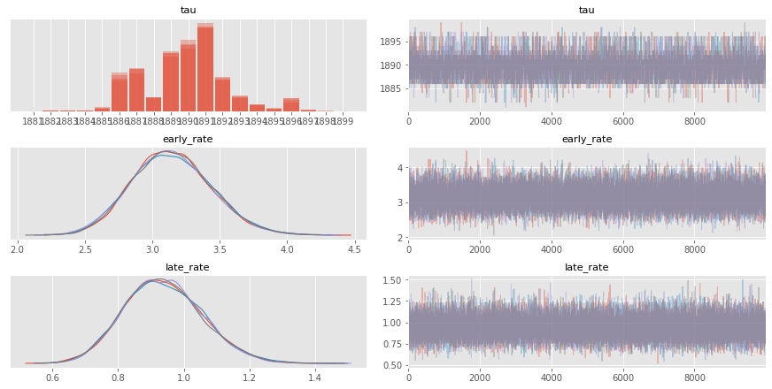

```python
az.plot_trace(trace);
```

```python
az.summary(trace, round_to=2)
```

|  | mean | sd | hdi_3% | hdi_97% | mcse_mean | mcse_sd | ess_mean | ess_sd | ess_bulk | ess_tail | r_hat |
| --- | --- | --- | --- | --- | --- | --- | --- | --- | --- | --- | --- |
| tau | 1889.81 | 2.44 | 1886.00 | 1894.00 | 0.03 | 0.02 | 5581.22 | 5580.20 | 5752.74 | 6490.54 | 1.0 |
| early_rate | 3.14 | 0.30 | 2.60 | 3.70 | 0.00 | 0.00 | 23770.12 | 23770.12 | 23430.77 | 24830.83 | 1.0 |
| late_rate | 0.94 | 0.12 | 0.72 | 1.16 | 0.00 | 0.00 | 26139.89 | 26139.89 | 25941.38 | 24808.18 | 1.0 |

Оценим вероятность того, что $\lambda_1$ отличается от $\lambda_2$:

```python
np.mean(trace["early_rate"] - trace["late_rate"] > 0)
```

```
1.0
```

Можно задаться более сложным вопросом, например: "Какова вероятность, что значения различаются по крайней мере на $1$? На $2$? На $3$? На $5$?

```python
for d in [1,2,3,5]:
    v = np.mean(np.abs(trace["early_rate"] - trace["late_rate"]) > d)
    print(f'Вероятность того, что значения различаются более, чем на {d} равна {v}')
```

```
Вероятность того, что значения различаются более, чем на 1 равна 1.0
Вероятность того, что значения различаются более, чем на 2 равна 0.7398
Вероятность того, что значения различаются более, чем на 3 равна 0.008075
Вероятность того, что значения различаются более, чем на 5 равна 0.0
```

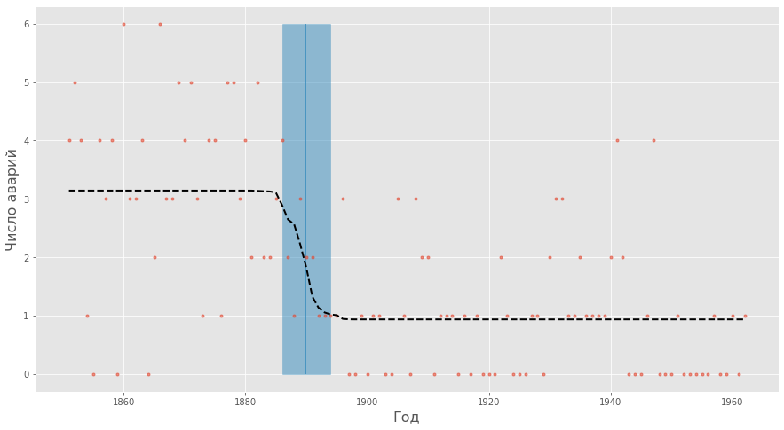

```python
plt.figure(figsize=(15, 8))
plt.plot(years, y, ".", alpha=0.6)
plt.ylabel("Число аварий", fontsize=16)
plt.xlabel("Год", fontsize=16)

plt.vlines(
    trace["tau"].mean(), y.min(), y.max(), color="C1"
)

average_disasters = np.zeros_like(y, dtype="float")

for i, year in enumerate(years):
    idx = year < trace["tau"]
    average_disasters[i] = (
        trace["early_rate"][idx].sum() + trace["late_rate"][~idx].sum()
    ) / (len(trace) * trace.nchains)

sp_hpd = az.hdi(trace["tau"])

plt.fill_betweenx(
    y=[y.min(), y.max()],
    x1=sp_hpd[0],
    x2=sp_hpd[1],
    alpha=0.5,
    color="C1",
)

plt.plot(years, average_disasters, "k--", lw=2);
```

# 3. Регрессия - моя профессия

По аналогии можно оценивать более сложные модели. Например, регрессию. Воспользуемся данными по рекламе и продажам на разных рынках.

```python
df = pd.read_csv('Advertising.csv', index_col=0)
print(df.shape)
df.head()
```

```
(200, 4)
```

|  | TV | Radio | Newspaper | Sales |
| --- | --- | --- | --- | --- |
| 1 | 230.1 | 37.8 | 69.2 | 22.1 |
| 2 | 44.5 | 39.3 | 45.1 | 10.4 |
| 3 | 17.2 | 45.9 | 69.3 | 9.3 |
| 4 | 151.5 | 41.3 | 58.5 | 18.5 |
| 5 | 180.8 | 10.8 | 58.4 | 12.9 |

Прологарифмируем продажи и деньги, которые мы вложили на рекламу по тв.

```python
df['ln_TV'] = df['TV'].apply(np.log)
df['ln_Sales'] = df['Sales'].apply(np.log)

X = df[['ln_TV', 'Radio', 'Newspaper']].values
y = df.ln_Sales.values
```

Выбирем для коэффициентов априорные распределени. Мы про них знаем не особо много, поэтому будем выбирать высокие дисперсии. Дисперсия должна быть всегда положительной, поэтому для неё возьмём экспоненциальное распределение с высокой дисперсией.

```python
regression_model = pm.Model()

with regression_model:

    # Priors for unknown model parameters
    alpha = pm.Normal("alpha", mu=0, sigma=10)
    beta = pm.Normal("beta", mu=0, sigma=100,  shape=3) # ничего не знаем про коэффициенты
    sigma = pm.Exponential("sigma", 0.01) # маленькая alpha => большая дисперсия 1/alpha^2

    X = pm.Data("pred", X)
    # Expected value of outcome
    mu = alpha + X@beta

    # Likelihood (sampling distribution) of observations
    y_obs = pm.Normal("y_obs", mu=mu, sigma=sigma, observed=y)
```

Запускаем обучение.

```python
with regression_model:
    trace = pm.sample(5000, return_inferencedata=False, model=regression_model)
```

```
Auto-assigning NUTS sampler...
Initializing NUTS using jitter+adapt_diag...
Multiprocess sampling (4 chains in 4 jobs)
NUTS: [sigma, beta, alpha]
```

100.00% [24000/24000 00:26<00:00 Sampling 4 chains, 0 divergences]

```
Sampling 4 chains for 1_000 tune and 5_000 draw iterations (4_000 + 20_000 draws total) took 35 seconds.
The acceptance probability does not match the target. It is 0.8846316146129201, but should be close to 0.8. Try to increase the number of tuning steps.
```

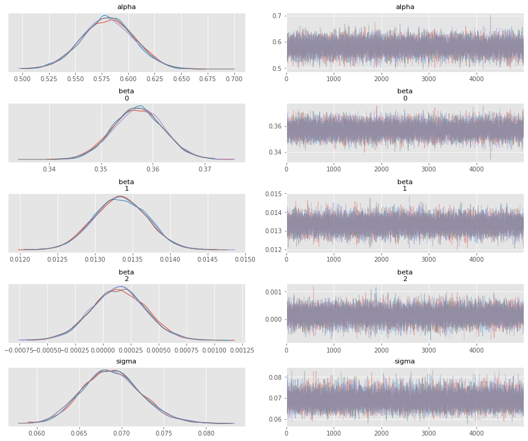

```python
az.plot_trace(trace);
```

```python
az.summary(trace, round_to=2)
```

|  | mean | sd | hdi_3% | hdi_97% | mcse_mean | mcse_sd | ess_mean | ess_sd | ess_bulk | ess_tail | r_hat |
| --- | --- | --- | --- | --- | --- | --- | --- | --- | --- | --- | --- |
| alpha | 0.58 | 0.02 | 0.53 | 0.63 | 0.0 | 0.0 | 10215.18 | 10215.18 | 10220.66 | 11305.06 | 1.0 |
| beta[0] | 0.36 | 0.00 | 0.35 | 0.37 | 0.0 | 0.0 | 10660.28 | 10660.28 | 10663.48 | 11518.82 | 1.0 |
| beta[1] | 0.01 | 0.00 | 0.01 | 0.01 | 0.0 | 0.0 | 14899.70 | 14879.58 | 14887.70 | 12194.88 | 1.0 |
| beta[2] | 0.00 | 0.00 | -0.00 | 0.00 | 0.0 | 0.0 | 14139.66 | 10712.54 | 14142.87 | 12040.14 | 1.0 |
| sigma | 0.07 | 0.00 | 0.06 | 0.08 | 0.0 | 0.0 | 12737.93 | 12737.93 | 12287.77 | 9544.37 | 1.0 |

Найдём вероятность того, что коэффициенты отличаются от нуля.

```python
trace['beta'].shape
```

```
(20000, 3)
```

```python
np.mean(trace['beta'] > 0, axis=0)
```

```
array([1.     , 1.     , 0.72035])
```

```python
# не забывайте о то, что мы работаем с выборками из апостериорных распределений
np.mean(trace['beta'] > 1e-2, axis=0)
```

```
array([1., 1., 0.])
```

Посмотрим на байесовские интервалы для наших коэффициентов.

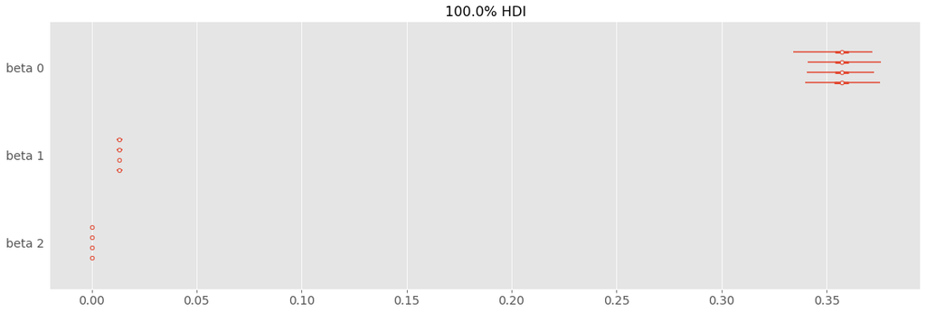

```python
pm.forestplot(trace, varnames=['beta'], hdi_prob=0.9999, figsize=(15, 5));
```

Эту же модель можно использовать для прогнозирования!

```python
X_new = np.array([[1.2, 4, 3], [5, 47, 120]])
```

```python
with regression_model:
    pm.set_data({"pred": X_new})
    model_preds = pm.sample_posterior_predictive(trace, var_names=["y_obs"])["y_obs"]
```

100.00% [20000/20000 00:49<00:00]

```python
model_preds.shape
```

```
(20000, 2)
```

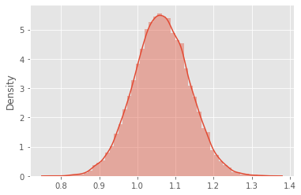

```python
sns.distplot(model_preds[:,0]);
```

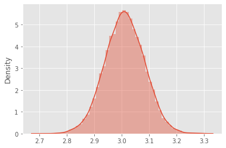

```python
sns.distplot(model_preds[:,1]);
```

# Материалы:

- [Ещё модели](https://docs.pymc.io/nb_examples/index.html)
- [Отличная простая книга про вероятностное программирование на python на pymc3](https://github.com/CamDavidsonPilon/Probabilistic-Programming-and-Bayesian-Methods-for-Hackers)
- [Введение в MCMC](https://twiecki.io/blog/2015/11/10/mcmc-sampling/)
- Ещё одна хорошая книга [Statistical rethinking](http://xcelab.net/rm/statistical-rethinking/) с примерами в R и pymc3